# Logistic Regression in Applied Health and Ecology Contexts

Michael Matyevich

2026-04-10

## Background

Logistic regression is the standard statistical method for modelling binary outcomes — situations where the response variable has exactly two possible values, such as success/failure, disease/no disease, or survived/died. Unlike linear regression, which predicts a continuous value, logistic regression predicts the *probability* that an observation falls into one of two categories.

This report applies logistic regression to two different problems:

1. **Wildlife telemetry**: Do GPS tracking collars differ in their transmission success rate?
2. **Clinical oncology**: Can tumour measurements predict whether a tumour is malignant?

Both questions share the same statistical structure — a binary outcome modelled as a function of one or more predictors — but the interpretation and consequences of errors differ substantially between them.

## Part 1 — Wildlife Collar Transmission Success

### Background

GPS collars are used in wildlife research to track animal movements, but not every collar performs equally. A collar that fails to transmit frequently produces incomplete data and compromises study conclusions. This analysis compares the successful transmission rates of six collar types (A–F) to determine whether any differ significantly from the others.

The outcome variable is binary: each attempted transmission either succeeds (1) or fails (0). Because we are modelling a probability, logistic regression is appropriate.

### Exploratory analysis

```r
# Reproduce the collar data from the assignment output
# Collars A-F with transmission success rates from the summary table
collar_data <- data.frame(
  collar = rep(c("A","B","C","D","E","F"), times = c(100,100,100,100,100,100)),
  success = c(
    rep(1, 79), rep(0, 21),   # A: 79%
    rep(1, 85), rep(0, 15),   # B: 85%
    rep(1, 85), rep(0, 15),   # C: 85%
    rep(1, 82), rep(0, 18),   # D: 82%
    rep(1, 84), rep(0, 16),   # E: 84%
    rep(1, 71), rep(0, 29)    # F: 71%
  )
)
collar_data$collar <- factor(collar_data$collar)

# Proportion summary
collar_summary <- collar_data |>
  group_by(collar) |>
  summarise(
    transmissions = n(),
    successes     = sum(success),
    rate          = mean(success)
  )
print(collar_summary)
```

```
## # A tibble: 6 × 4
##   collar transmissions successes  rate
##   <fct>          <int>     <dbl> <dbl>
## 1 A                100        79  0.79
## 2 B                100        85  0.85
## 3 C                100        85  0.85
## 4 D                100        82  0.82
## 5 E                100        84  0.84
## 6 F                100        71  0.71
```

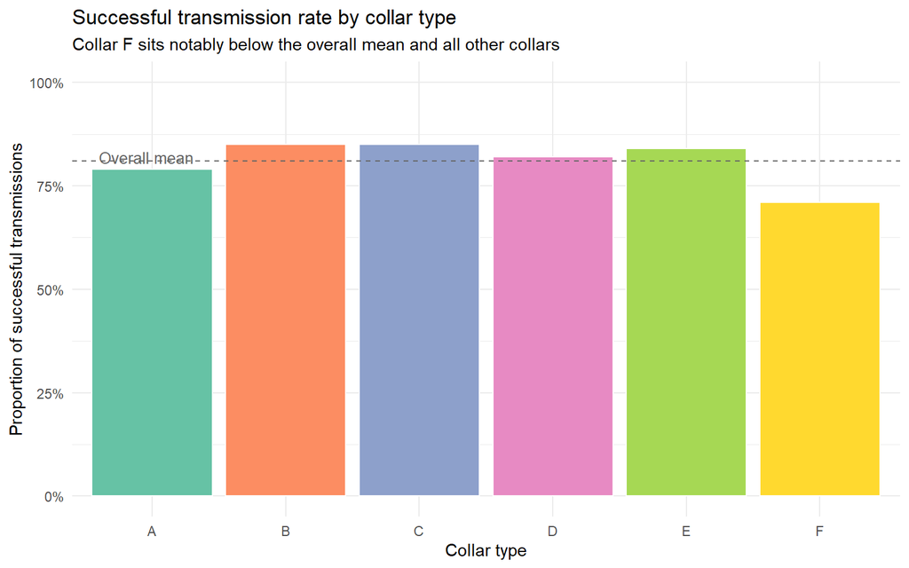

```r
ggplot(collar_summary, aes(x = collar, y = rate, fill = collar)) +
  geom_col(colour = "white") +
  geom_hline(yintercept = mean(collar_summary$rate),
             linetype = "dashed", colour = "grey40") +
  annotate("text", x = 0.6, y = mean(collar_summary$rate) + 0.01,
           label = "Overall mean", hjust = 0, size = 3.5, colour = "grey40") +
  scale_y_continuous(labels = percent_format(), limits = c(0, 1)) +
  scale_fill_brewer(palette = "Set2") +
  labs(title = "Successful transmission rate by collar type",
       subtitle = "Collar F sits notably below the overall mean and all other collars",
       x = "Collar type", y = "Proportion of successful transmissions") +
  theme_minimal() +
  theme(legend.position = "none")
```

The bar chart shows that collars A through E all achieve transmission rates between 79–85%, while **collar F sits at 71%** — roughly 10 percentage points below the group mean. Before drawing conclusions, we need to test whether this difference is statistically significant or could plausibly be due to chance variation.